# John_Smith_MachineLearning_ZehuaZhou

## General

Your task is to visualize labour / employment data ((https://www150.statcan.gc.ca/n1/daily-quotidien/190308/dq190308a-eng.htm) for Canada by province and industry for the last 5 years which should be pivotable by demographic (age, sex, ethnicity and industry / sector).

Use open skills data and job titles using this link and visualize a mashup correlating skills and jobs to industry and employment and provide a sample for evaluation.

Suggest in detail, how you would train these two data sets over time and what machine learning algorithm you would use to make the data "smarter" over time.

## Submission Process:

Please begin by creating a Project. Your Project should contain both the final output and a Github link to your source code. Please name all of your files and documents using the following convention: John_Smith_MachineLearning_Nameofyourfile. Once it is completed, you will be able to submit it here to the Work Challenge.

## Evaluation Criteria:

25% on your approach to tackling the problem and the steps you took to get to your solution and final deliverable 25% on how well you used various tools & processes to tackle the challenge 50% on the final solution and output of your challenge

## DataSet Reference:

DataSet source:

[1] Province, Gender, Age: [Labour force characteristics by province, monthly, seasonally adjusted](https://www150.statcan.gc.ca/t1/tbl1/en/cv.action?pid=1410028701)

[2] Industry: [Labour force characteristics by industry, annual](https://www150.statcan.gc.ca/t1/tbl1/en/cv.action?pid=1410035501)

[3] Given DataSet: [Job Skills](https://drive.google.com/file/d/1_f58raTn2fwGCMCL3EYZAfhMfSq2di8t/view?usp=sharing)

## Task:

EDA(Exploratory data analysis) these DataSet, discover valuable infomation and predict some import index

## Achievement

1. analyze unemployment rate of gender/age/industry for different province
2. analyze employment situation of gender/age/industry for different province
3. analyze popular skills/industry/hiring location
4. predict umemployment rate based on emplotyment via supervised learning algorithm

```python
import numpy as np
import pandas as pd
import seaborn as sns
import matplotlib.pyplot as plt
import sklearn
```

# 1 Data Preprocessing

## 1.1 Import Data

Import data that we download from LFS and google drive

```python
character_ORdf = pd.read_csv('charcter.csv')
industry_ORdf = pd.read_csv('industry.csv')
job_ORdf = pd.read_csv('job_skills.csv')
```

## 1.2 Data Understand and Cleaning

1. We need: Location, Age, Gender, Industry, Ethnicity(Didnt find). So we fillter other.
2. Some fields are null, we can delate. But for some fields that no need to delete, we can keep first.
3. Standardize data type.

### 1.2.1 Labour Force Characteristic data

```python
character_df = character_ORdf[['REF_DATE','GEO', 'Labour force characteristics','Sex', 'Age group', 'VALUE', 'SCALAR_FACTOR']]
character_df.columns = ['Date', 'Prov', 'Char', 'Sex', 'Age', 'Value', 'Scalar']
character_df['Date'] = character_df['Date'].astype('str')
character_df['Prov'] = character_df['Prov'].astype('category')
character_df['Char'] = character_df['Char'].astype('category')
character_df.info()
```

```
<class 'pandas.core.frame.DataFrame'>
RangeIndex: 77380 entries, 0 to 77379
Data columns (total 7 columns):
Date      77380 non-null object
Prov      77380 non-null category
Char      77380 non-null category
Sex       77380 non-null object
Age       77380 non-null object
Value     77380 non-null float64
Scalar    77380 non-null object
dtypes: category(2), float64(1), object(4)
memory usage: 3.1+ MB
```

```python
character_df.head(2)
```

|  | Date | Prov | Char | Sex | Age | Value | Scalar |
| --- | --- | --- | --- | --- | --- | --- | --- |
| 0 | 2015-10 | Canada | Population | Both sexes | 15 years and over | 29377.5 | thousands |
| 1 | 2015-11 | Canada | Population | Both sexes | 15 years and over | 29401.2 | thousands |

### 1.2.2 Industry data

```python
industry_df = industry_ORdf[['REF_DATE', 'GEO', 'North American Industry Classification System (NAICS)', 'VALUE', 'SCALAR_FACTOR']]
industry_df.columns = ['Date', 'Prov', 'Industry', 'Value', 'Scalar']
industry_df['Date'] = industry_df['Date'].astype('str')
industry_df['Industry'] = industry_df['Industry'].astype('category')
industry_df['Value'] = industry_df['Value'].astype('float64')
industry_df.info()
```

```
<class 'pandas.core.frame.DataFrame'>
RangeIndex: 11077 entries, 0 to 11076
Data columns (total 5 columns):
Date        11077 non-null object
Prov        11077 non-null object
Industry    11077 non-null category
Value       11069 non-null float64
Scalar      11077 non-null object
dtypes: category(1), float64(1), object(3)
memory usage: 357.9+ KB
```

Check integrity: 'Value' has 8 Nulls. Since 'Value' necessary, so filtered it out. Note: Sometimes records are not allowed to drop, we can also fill up with the average/median.

```python
industry_df.dropna(inplace=True)
industry_df.head(2)
```

|  | Date | Prov | Industry | Value | Scalar |
| --- | --- | --- | --- | --- | --- |
| 0 | 2015-10 | Canada | Total employed, all industries | 18007.1 | thousands |
| 1 | 2015-11 | Canada | Total employed, all industries | 17986.6 | thousands |

### 1.2.3 Job skills data

```python
job_df = job_ORdf.rename(columns={'Minimum Qualifications':'Minimum', 'Preferred Qualifications':'Prefer'})
job_df['Category'] = job_df['Category'].astype('category')
job_df.info()
```

```
<class 'pandas.core.frame.DataFrame'>
RangeIndex: 1250 entries, 0 to 1249
Data columns (total 7 columns):
Company             1250 non-null object
Title               1250 non-null object
Category            1250 non-null category
Location            1250 non-null object
Responsibilities    1235 non-null object
Minimum             1236 non-null object
Prefer              1236 non-null object
dtypes: category(1), object(6)
memory usage: 60.7+ KB
```

Responsibilties, Minmum and Prefer are missing 15/14/14 records, we temporarily keep it.

```python
job_df.head(2)
```

|  | Company | Title | Category | Location | Responsibilities | Minimum | Prefer |
| --- | --- | --- | --- | --- | --- | --- | --- |
| 0 | Google | Google Cloud Program Manager | Program Management | Singapore | Shape, shepherd, ship, and show technical prog... | BA/BS degree or equivalent practical experienc... | Experience in the business technology market a... |
| 1 | Google | Supplier Development Engineer (SDE), Cable/Con... | Manufacturing & Supply Chain | Shanghai, China | Drive cross-functional activities in the suppl... | BS degree in an Engineering discipline or equi... | BSEE, BSME or BSIE degree.\nExperience of usin... |

# 2 Data Analysis and Visualization

## 2.1 Labour Characteristic Analysis

### 2.1.1 Portion of Different Ages

For employment, the value is based on the average value of 2015.10-2020.02, taking Canada, Ontario, Quebec as an example.

```python
# filter date/sex
emp_df = character_df[(character_df['Char']=='Employment')&
                                 (character_df['Sex']=='Both sexes')]
# filter age
emp_df = emp_df[(emp_df['Age']=='15 to 24 years') |
                        (emp_df['Age']=='25 to 54 years')|
                        (emp_df['Age']=='55 years and over')]
# filter Provience
CA_emp_df =emp_df[emp_df['Prov']=='Canada'].groupby('Age').agg('mean')
ON_emp_df =emp_df[emp_df['Prov']=='Ontario'].groupby('Age').agg('mean')
QC_emp_df =emp_df[emp_df['Prov']=='Quebec'].groupby('Age').agg('mean')
```

[figure not shown]

```python
label_names = ['15 to 24 years', '25 to 54 years', '55 years and over']

plt.figure(figsize=(15, 15))
plt.subplot(231)
plt.pie(CA_emp_df['Value'].to_list(), labels=label_names, autopct='%1.1f%%', radius=1, shadow=True, startangle=90)
plt.title('Age Distribution in Canada in Oct. 2019')

plt.subplot(232)
plt.pie(ON_emp_df['Value'].to_list(), labels=label_names, autopct='%1.1f%%', radius=1, shadow=True, startangle=90)
plt.title('Age Distribution in Ontario in Oct. 2019')

plt.subplot(233)
plt.pie(QC_emp_df['Value'].to_list(), labels=label_names, autopct='%1.1f%%', radius=1, shadow=True, startangle=90)
plt.title('Age Distribution in Quebec in Oct. 2019')

plt.show()
```

在社会中25-54岁的人群是主力, 占到了65%左右. 15-24岁的青少年占比非常少.

## 2.1.2 Unemployment Rare for Province

We extract unemployment rate from character_df, and draw a line chart

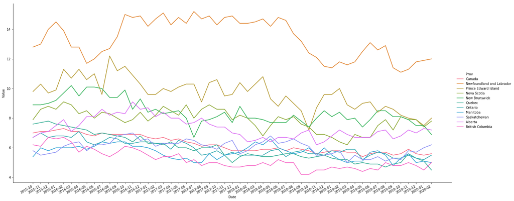

```python
unemp_rate_df = character_df[(character_df['Char']=='Unemployment rate')&
                             (character_df['Sex']=='Both sexes')&
                            (character_df['Age']=='15 years and over')]
g = sns.relplot(x='Date', y='Value', data=unemp_rate_df, hue='Prov',
           kind='line', height=10,linewidth=2,aspect=2)
g.fig.autofmt_xdate()
```

By comparing the provinces, we find that the best performer is BC, which has always been in a relatively low position. The worst is Newfoundland and Labrador. Since 2015, the unemployment rate has remained high.

## 2.1.3 Unemployment Rate of Genders

Take Ontario for example.

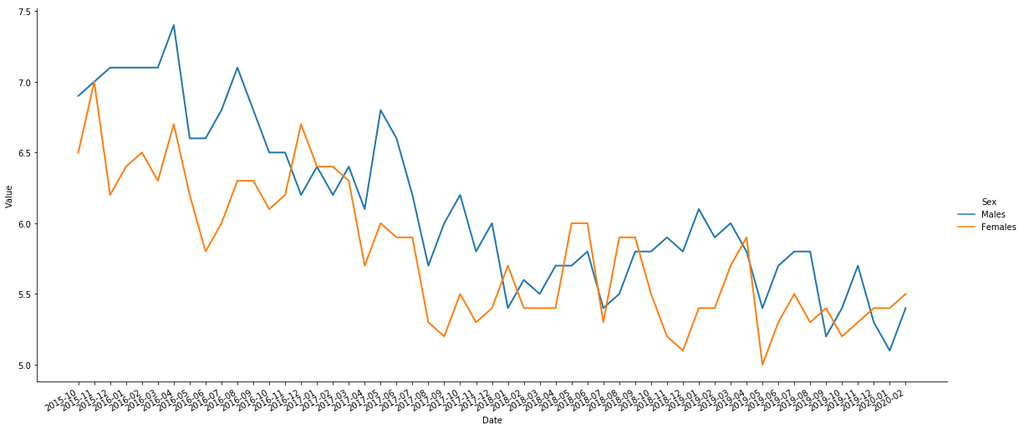

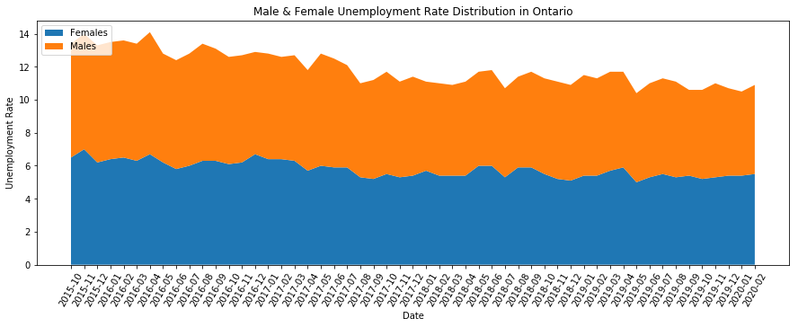

```python
unemp_rate_df = character_df[(character_df['Char']=='Unemployment rate')&
                             (character_df['Sex']!='Both sexes')&
                            (character_df['Age']=='15 years and over')]
unemp_rate_df = unemp_rate_df[unemp_rate_df['Prov']=='Ontario']
g = sns.relplot(x='Date', y='Value', data=unemp_rate_df, hue='Sex',
           kind='line', height=8,linewidth=2,aspect=2)
g.fig.autofmt_xdate()
g.set_titles('Male & Female Unemployment Rate Distribution in Ontario')

unemp_rate_df = unemp_rate_df.pivot_table(index='Sex', columns='Date').Value
labels = ['Females', 'Males']
x = unemp_rate_df.columns.tolist()
plt.figure(figsize=(15, 5))
plt.stackplot(x, unemp_rate_df.loc['Females'], unemp_rate_df.loc['Males'], labels=labels)
plt.legend(loc = 'upper left')
plt.xlabel('Date')
plt.xticks(rotation=60)
plt.ylabel('Unemployment Rate')
plt.title('Male & Female Unemployment Rate Distribution in Ontario')
plt.show()
```

By comparing the unemployment rate of male and female, usually, the unemployment rate of female is lower, and the unemployment rate will be lower around July each year.

## 2.1.4 Unemployment Rate of Ages

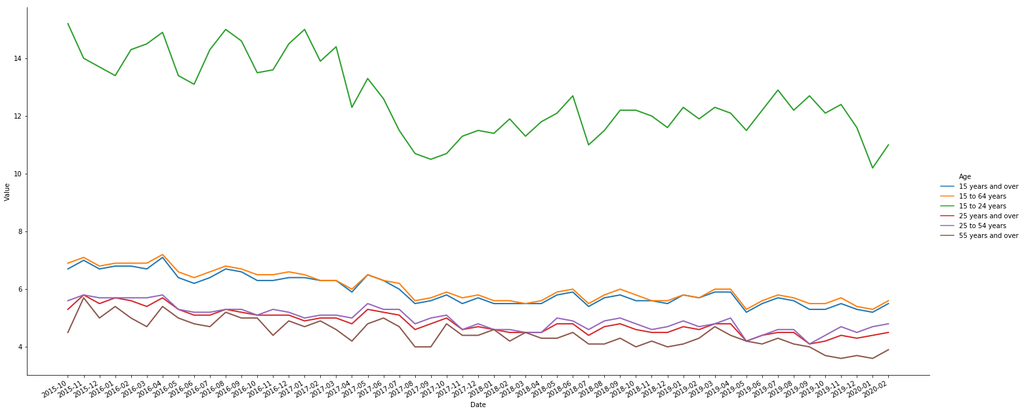

```python
unemp_rate_df = character_df[(character_df['Char']=='Unemployment rate')&
                             (character_df['Sex']=='Both sexes')]
unemp_rate_df = unemp_rate_df[unemp_rate_df['Prov']=='Ontario']
g = sns.relplot(x='Date', y='Value', data=unemp_rate_df, hue='Age',
           kind='line', height=10,linewidth=2,aspect=2)
g.fig.autofmt_xdate()
```

We compare all different ages, and there is a huge gap between top line and other lines. Now we only check other lines.

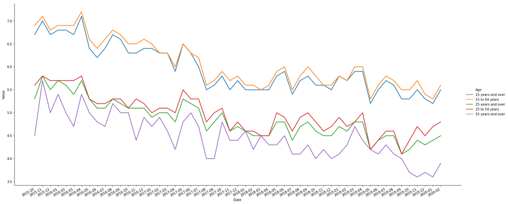

```python
unemp_rate_df = character_df[(character_df['Char']=='Unemployment rate')&
                             (character_df['Sex']=='Both sexes')&
                             (character_df['Age']!='15 to 24 years')]
unemp_rate_df = unemp_rate_df[unemp_rate_df['Prov']=='Ontario']
g = sns.relplot(x='Date', y='Value', data=unemp_rate_df, hue='Age',
           kind='line', height=10,linewidth=2,aspect=2)
g.fig.autofmt_xdate()
```

The highest unemployment rate is for young people aged 15-24. This high unemployment rate is understandable, because young people at this stage may be in school or don't have work experience. Combined with the analysis of 2.1, this part of the population is also the smallest. This situation will become better with age rising. The unemployment rate generally decreases. The good news is that from October 2015 to the present, the unemployment rate gradually decreases.

## 2.2 Industry Analysis

### 2.2.1 Two Basic Industry

[figure not shown]

```python
genIndustry_df = industry_df[(industry_df['Industry']=='Total employed, all industries')|
           (industry_df['Industry']=='Goods-producing sector')|
           (industry_df['Industry']=='Services-producing sector')]
genIndustry_df = genIndustry_df.pivot_table(index='Industry', columns='Date').reset_index()
genIndustry_df = genIndustry_df.Value.T.rename(columns=genIndustry_df.Industry.T.to_dict())
genIndustry_df.reset_index(inplace=True)
f, ax = plt.subplots(figsize=(6, 15))

sns.set_color_codes("pastel")
sns.barplot(x="Total employed, all industries", y="Date", data=genIndustry_df,
            label="Goods-producing sector", color="b")

sns.set_color_codes("muted")
sns.barplot(x="Services-producing sector", y="Date", data=genIndustry_df,
            label="Services-producing sector", color="b")

ax.legend(ncol=2, loc="lower right", frameon=True)
ax.set(ylabel="",
       xlabel="Automobile collisions per billion miles")
sns.despine(left=True, bottom=True)
```

```python
genIndustry_df['Service_ratio'] = genIndustry_df['Services-producing sector']/genIndustry_df['Total employed, all industries']
genIndustry_df.describe()
```

|  | Goods-producing sector | Services-producing sector | Total employed, all industries | Service_ratio |
| --- | --- | --- | --- | --- |
| count | 53.000000 | 53.000000 | 53.000000 | 53.000000 |
| mean | 709.248542 | 2662.609434 | 3371.854889 | 0.789617 |
| std | 9.866068 | 63.225158 | 71.426748 | 0.002483 |
| min | 690.909091 | 2564.463636 | 3270.300000 | 0.783560 |
| 25% | 699.527273 | 2609.209091 | 3305.718182 | 0.788194 |
| 50% | 711.609091 | 2657.672727 | 3374.436364 | 0.789664 |
| 75% | 717.745455 | 2718.172727 | 3434.790909 | 0.791048 |
| max | 724.663636 | 2767.272727 | 3488.972727 | 0.795061 |

## 2.2.2 Sub-Industry Employment

We compare for the change of industries in a detailed standard. Take Ontario as example.

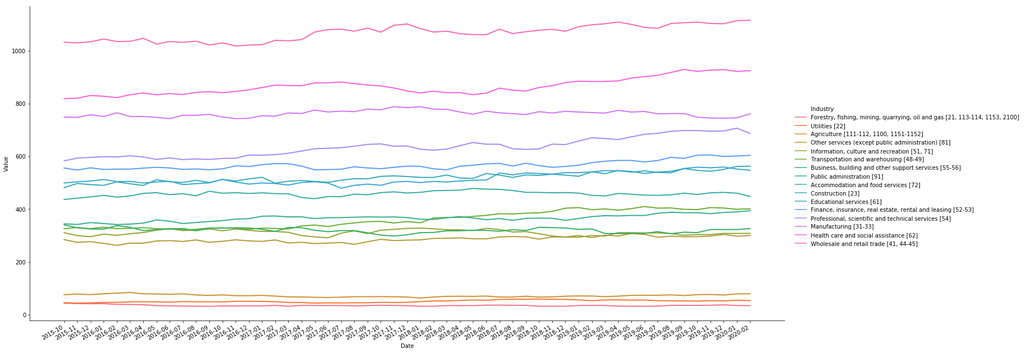

```python
subIndustry_df = industry_df[(industry_df['Prov']=='Ontario')]
subIndustry_df.sort_values(['Date', 'Value'], inplace=True)
g = sns.relplot(x='Date', y='Value', data=subIndustry_df[(industry_df['Industry']!='Total employed, all industries')&
           (industry_df['Industry']!='Goods-producing sector')&
           (industry_df['Industry']!='Services-producing sector')],
            hue='Industry', kind='line', height=10,linewidth=2,aspect=2)
g.fig.autofmt_xdate()
```

## 2.2.3 Growth Rate of the Sub-industries

```python
subIndustry_df = subIndustry_df.sort_values(['Industry', 'Date']).reset_index()[['Date', 'Prov', 'Industry', 'Value']]
value_diff = subIndustry_df.groupby('Industry').apply(lambda x:x.Value-x.Value.shift()).reset_index()['Value']
subIndustry_df['Value_diff'] = value_diff
subIndustry_df['Value_change_ratio'] = subIndustry_df['Value_diff']/subIndustry_df['Value']
subIndustry_df.head(3)
```

|  | Date | Prov | Industry | Value | Value_diff | Value_change_ratio |
| --- | --- | --- | --- | --- | --- | --- |
| 0 | 2015-10 | Ontario | Accommodation and food services [72] | 437.2 | NaN | NaN |
| 1 | 2015-11 | Ontario | Accommodation and food services [72] | 442.2 | 5.0 | 0.011307 |
| 2 | 2015-12 | Ontario | Accommodation and food services [72] | 446.7 | 4.5 | 0.010074 |

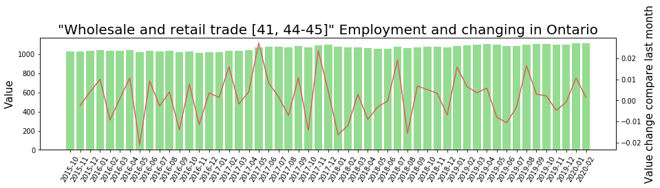

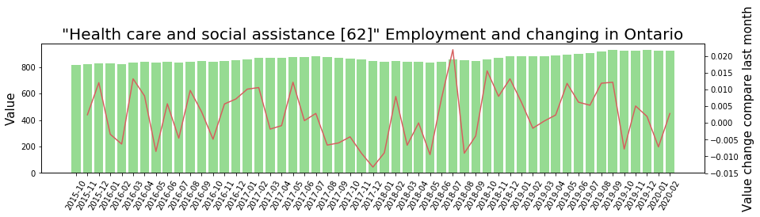

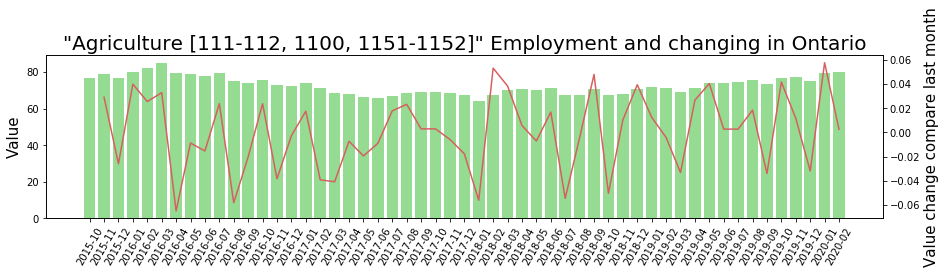

```python
def draw(name):
    sub_df = subIndustry_df[subIndustry_df['Industry']==name]
    x = sub_df['Date']
    y1 = sub_df['Value']
    y2 = sub_df['Value_change_ratio']
    fig = plt.figure(figsize=(15, 3))

    # bar chart
    ax1 = fig.add_subplot(111)
    ax1.bar(x, y1,alpha=.7,color='g')
    ax1.set_ylabel('Value',fontsize='15')

    # line chart
    ax2 = ax1.twinx()   # joint chart needed
    ax2.plot(x, y2, 'r',ms=10)
    ax2.set_ylabel('Value change compare last month',fontsize='15')
    # rotation the x labels, look better
    [tick.set_rotation(60) for tick in ax1.get_xticklabels()]
    plt.title('"{}" Employment and changing in Ontario'.format(name), fontsize='20')
    plt.show()

industry_class = subIndustry_df.Industry.value_counts().index
# only show first 3 Industry
for name in industry_class[0:3]:
    draw(name)
```

Through analysis, we found that in 2017-02, the Wholesale and retail trade industry developed stable, but Agriculture was very sensitive to time changes, which may be related to the season.

Here we have a thought, whether the overall industry development status is related to the unemployment rate? This will be introduced in the machine learning section later.

## 2.3 Job Skills Analysis

Visualization according to the characteristics of Job Skills

```python
job_df.describe()
```

|  | Company | Title | Category | Location | Responsibilities | Minimum | Prefer |
| --- | --- | --- | --- | --- | --- | --- | --- |
| count | 1250 | 1250 | 1250 | 1250 | 1235 | 1236 | 1236 |
| unique | 2 | 794 | 23 | 92 | 801 | 807 | 821 |
| top | Google | Business Intern 2018 | Sales & Account Management | Mountain View, CA, United States | Responsibilities and detailed projects will be... | Must be pursuing a full-time MBA program with ... | Interest in the technology industry and Google... |
| freq | 1227 | 35 | 168 | 190 | 33 | 32 | 32 |

We found that Catergory has 23 categories, mainly from Google, with a total of 92 different locations and 190 positions from Mountain View, CA, United States. Therefore, we can perform the first step analysis on the category and the location of the recruitment source.

### 2.3.1 Category Portion

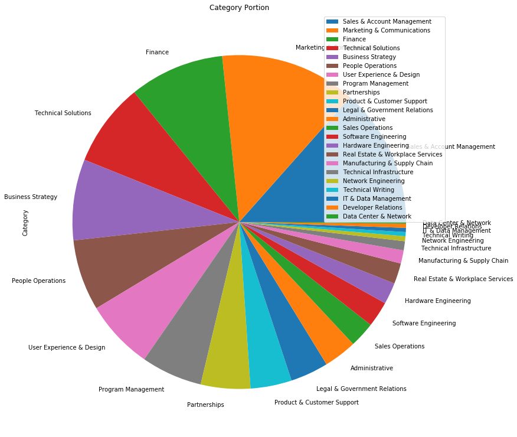

```python
job_df.Category.value_counts().to_frame().plot.pie(y='Category', figsize=(13, 13), title='Category Portion')
```

### 2.3.2 Location Portion

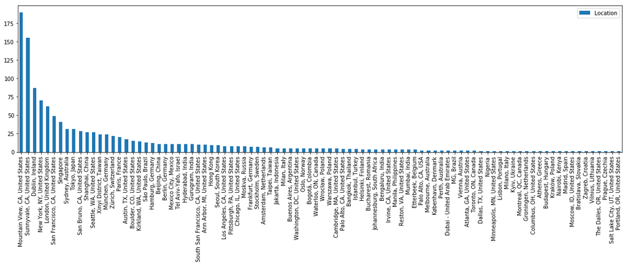

```python
job_df.Location.value_counts().to_frame().plot.bar(figsize=(20, 5))
```

### 2.3.3 Top Minimum Skills

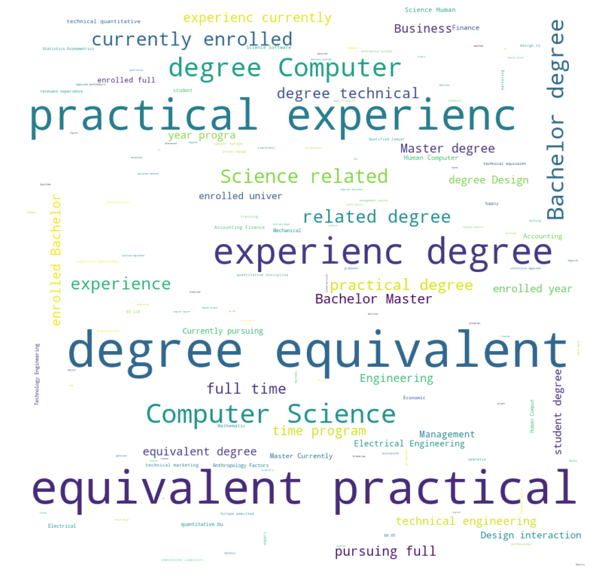

```python
from wordcloud import WordCloud
import nltk
# first time runn it. you have to download some packages.
# nltk.download('punkt')
# nltk.download('averaged_perceptron_tagger')
# nltk.download('stopwords')
from nltk.corpus import stopwords

text = job_df.Minimum.to_string()
text_list = nltk.word_tokenize(text)
english_punctuations = [',', '.', ':', ';', '?', '(', ')', '[', ']', '&', '!', '*', '@', '#', '$', '%']
text_list = [word for word in text_list if word not in english_punctuations]

stops = set(stopwords.words("english"))
text_list = [word for word in text_list if word not in stops]
text_list = [word for word in text_list if len(word)>5]    # filter words less than 5 char like 'is', 'and', ' with'
text_string = " ".join(text_list)

plt.figure(figsize=(15, 15))
wordcloud = WordCloud(background_color="white",width=1000,height=1000).generate(text_string)
plt.imshow(wordcloud, interpolation="bilinear")
plt.axis("off")
plt.show()
```

# 3 Build mode

## 3.1 Issues we want to solve

We know that the unemployment rate is an important indicator that reflects social development. Through previous analysis, how to predict the unemployment rate?

Based on the above analysis, it was decided to build a model:

## 3.2 Feature Engineering

### 3.2.1 Collect Features

#### 3.2.1.1 From Industry Employment

```python
industry_emp_df = subIndustry_df.pivot_table(index=['Date'],columns=['Industry'],values=['Value']).Value
industry_emp_df.head(2)
```

| Industry Date | Accommodation and food services [72] | Agriculture [111-112, 1100, 1151-1152] | Business, building and other support services [55-56] | Construction [23] | Educational services [61] | Finance, insurance, real estate, rental and leasing [52-53] | Forestry, fishing, mining, quarrying, oil and gas [21, 113-114, 1153, 2100] | Goods-producing sector | Health care and social assistance [62] | Information, culture and recreation [51, 71] | Manufacturing [31-33] | Other services (except public administration) [81] | Professional, scientific and technical services [54] | Public administration [91] | Services-producing sector | Total employed, all industries | Transportation and warehousing [48-49] | Utilities [22] | Wholesale and retail trade [41, 44-45] |
| --- | --- | --- | --- | --- | --- | --- | --- | --- | --- | --- | --- | --- | --- | --- | --- | --- | --- | --- | --- |
| 2015-10 | 437.2 | 76.6 | 340.9 | 482.3 | 499.7 | 556.1 | 44.2 | 1398.4 | 818.8 | 311.2 | 749.0 | 285.1 | 583.4 | 344.8 | 5536.6 | 6935.0 | 326.8 | 46.2 | 1032.7 |
| 2015-11 | 442.2 | 78.9 | 329.9 | 497.7 | 503.9 | 548.4 | 43.0 | 1412.4 | 820.8 | 300.4 | 748.1 | 274.8 | 593.7 | 342.6 | 5517.9 | 6930.3 | 330.9 | 44.7 | 1030.2 |

#### 3.2.1.2 From Age/Gender Employment

```python
emp_df = character_df[(character_df['Char']=='Employment')]
emp_df = emp_df[emp_df['Prov']=='Ontario']
sex_emp_df = emp_df.pivot_table(index=['Date'],columns=['Sex'],values=['Value']).Value
age_emp_df = emp_df.pivot_table(index=['Date'],columns=['Age'],values=['Value']).Value
age_emp_df.head(2)
```

| Age Date | 15 to 24 years | 15 to 64 years | 15 years and over | 25 to 54 years | 25 years and over | 55 years and over |
| --- | --- | --- | --- | --- | --- | --- |
| 2015-10 | 609.533333 | 4408.4 | 5202.925 | 3051.833333 | 4013.8 | 961.966667 |
| 2015-11 | 612.200000 | 4416.6 | 5201.650 | 3046.400000 | 4008.0 | 961.633333 |

### 3.2.1.3 Make Feature Map

```python
feature_df = pd.DataFrame()
for c in age_emp_df.columns:
    feature_df[c]=age_emp_df[c]
for c in sex_emp_df.columns:
    feature_df[c]=sex_emp_df[c]
for c in industry_emp_df.columns:
    feature_df[c]=industry_emp_df[c]
feature_df.head(2)
```

| Date | 15 to 24 years | 15 to 64 years | 15 years and over | 25 to 54 years | 25 years and over | 55 years and over | Both sexes | Females | Males | Accommodation and food services [72] | ... | Information, culture and recreation [51, 71] | Manufacturing [31-33] | Other services (except public administration) [81] | Professional, scientific and technical services [54] | Public administration [91] | Services-producing sector | Total employed, all industries | Transportation and warehousing [48-49] | Utilities [22] | Wholesale and retail trade [41, 44-45] |
| --- | --- | --- | --- | --- | --- | --- | --- | --- | --- | --- | --- | --- | --- | --- | --- | --- | --- | --- | --- | --- | --- |
| 2015-10 | 609.533333 | 4408.4 | 5202.925 | 3051.833333 | 4013.8 | 961.966667 | 4777.857143 | 2112.783333 | 2304.433333 | 437.2 | ... | 311.2 | 749.0 | 285.1 | 583.4 | 344.8 | 5536.6 | 6935.0 | 326.8 | 46.2 | 1032.7 |
| 2015-11 | 612.200000 | 4416.6 | 5201.650 | 3046.400000 | 4008.0 | 961.633333 | 4777.657143 | 2115.750000 | 2300.500000 | 442.2 | ... | 300.4 | 748.1 | 274.8 | 593.7 | 342.6 | 5517.9 | 6930.3 | 330.9 | 44.7 | 1030.2 |

2 rows × 28 columns

So far, we have constructed the data set, we can find that there are 28 Features, and 53 records.

### 3.2.2 Normalization

Among the features, some values are too large, which may cause the bias.In order to reduce the bias caused by the numerical range, we do normalization on the data.

```python
feature_df.describe()
```

|  | 15 to 24 years | 15 to 64 years | 15 years and over | 25 to 54 years | 25 years and over | 55 years and over | Both sexes | Females | Males | Accommodation and food services [72] | ... | Information, culture and recreation [51, 71] | Manufacturing [31-33] | Other services (except public administration) [81] | Professional, scientific and technical services [54] | Public administration [91] | Services-producing sector | Total employed, all industries | Transportation and warehousing [48-49] | Utilities [22] | Wholesale and retail trade [41, 44-45] |
| --- | --- | --- | --- | --- | --- | --- | --- | --- | --- | --- | --- | --- | --- | --- | --- | --- | --- | --- | --- | --- | --- |
| count | 53.000000 | 53.000000 | 53.000000 | 53.000000 | 53.000000 | 53.000000 | 53.000000 | 53.000000 | 53.000000 | 53.000000 | ... | 53.000000 | 53.000000 | 53.000000 | 53.000000 | 53.000000 | 53.000000 | 53.000000 | 53.000000 | 53.000000 | 53.000000 |
| mean | 635.995597 | 4582.849686 | 5402.547642 | 3129.742138 | 4166.340881 | 1036.596855 | 4961.995148 | 2202.440881 | 2386.025786 | 458.639623 | ... | 311.952830 | 762.371698 | 286.184906 | 635.643396 | 366.464151 | 5759.679245 | 7203.503774 | 361.832075 | 51.656604 | 1067.737736 |
| std | 18.738849 | 112.223398 | 142.396829 | 61.693624 | 110.585639 | 50.770250 | 129.013143 | 53.254044 | 66.893891 | 9.130114 | ... | 10.175774 | 11.878510 | 11.153378 | 35.865221 | 13.172759 | 169.153666 | 190.416651 | 31.958247 | 4.484782 | 29.601281 |
| min | 609.066667 | 4408.400000 | 5201.650000 | 3046.400000 | 4008.000000 | 961.633333 | 4777.657143 | 2112.783333 | 2300.500000 | 437.200000 | ... | 292.000000 | 743.200000 | 263.300000 | 583.400000 | 342.000000 | 5517.900000 | 6930.300000 | 322.000000 | 44.600000 | 1018.300000 |
| 25% | 620.966667 | 4480.566667 | 5271.750000 | 3086.666667 | 4064.600000 | 987.200000 | 4843.528571 | 2153.350000 | 2332.883333 | 452.900000 | ... | 304.300000 | 751.600000 | 277.500000 | 602.500000 | 358.100000 | 5615.000000 | 7028.300000 | 329.000000 | 47.600000 | 1036.400000 |
| 50% | 633.733333 | 4562.033333 | 5389.800000 | 3109.466667 | 4146.466667 | 1041.000000 | 4947.271429 | 2205.483333 | 2367.833333 | 459.900000 | ... | 311.400000 | 762.500000 | 285.100000 | 631.200000 | 366.900000 | 5729.100000 | 7181.500000 | 353.300000 | 51.400000 | 1072.500000 |
| 75% | 655.066667 | 4670.200000 | 5510.200000 | 3186.600000 | 4255.733333 | 1069.000000 | 5061.371429 | 2243.333333 | 2439.083333 | 463.200000 | ... | 320.800000 | 769.700000 | 295.600000 | 658.300000 | 373.700000 | 5891.600000 | 7349.100000 | 398.600000 | 55.500000 | 1091.400000 |
| max | 675.200000 | 4787.166667 | 5666.000000 | 3241.200000 | 4366.600000 | 1139.266667 | 5198.600000 | 2303.016667 | 2517.733333 | 478.900000 | ... | 328.500000 | 788.600000 | 308.100000 | 707.200000 | 394.700000 | 6080.900000 | 7558.300000 | 410.400000 | 59.900000 | 1115.900000 |

8 rows × 28 columns

According to the analysis of Features, we found that the overall change range of the feature is not large, and the difference between the maximum value and the minimum value is not huge, so we choose MinMaxScaler.

```python
from sklearn import preprocessing
min_max_scaler = preprocessing.MinMaxScaler()
X = pd.DataFrame(min_max_scaler.fit_transform(feature_df))
X.head(2)
```

|  | 0 | 1 | 2 | 3 | 4 | 5 | 6 | 7 | 8 | 9 | ... | 18 | 19 | 20 | 21 | 22 | 23 | 24 | 25 | 26 | 27 |
| --- | --- | --- | --- | --- | --- | --- | --- | --- | --- | --- | --- | --- | --- | --- | --- | --- | --- | --- | --- | --- | --- |
| 0 | 0.007056 | 0.000000 | 0.002746 | 0.027892 | 0.016174 | 0.001877 | 0.000475 | 0.000000 | 0.018106 | 0.000000 | ... | 0.526027 | 0.127753 | 0.486607 | 0.000000 | 0.053131 | 0.033215 | 0.007484 | 0.054299 | 0.104575 | 0.147541 |
| 1 | 0.047379 | 0.021649 | 0.000000 | 0.000000 | 0.000000 | 0.000000 | 0.000000 | 0.015595 | 0.000000 | 0.119904 | ... | 0.230137 | 0.107930 | 0.256696 | 0.083199 | 0.011385 | 0.000000 | 0.000000 | 0.100679 | 0.006536 | 0.121926 |

2 rows × 28 columns

### 3.2.3 Dimensionality Reduction

In the case of more features, in order to improve the training speed and prevent overfitting, we usually reduce the dimension of the data, but there are only 28 features here, so dimension reduction is not necessary.

```python
on_unemp_rate_df = character_df[(character_df['Char']=='Unemployment rate')&
                             (character_df['Sex']=='Both sexes')&
                            (character_df['Age']=='15 years and over')&
                            (character_df['Prov']=='Ontario')]
on_unemp_rate_df = on_unemp_rate_df.reset_index()[['Date', 'Value']].set_index('Date')
on_unemp_rate_df.head(2)
```

| Date | Value |
| --- | --- |
| 2015-10 | 6.7 |
| 2015-11 | 7.0 |

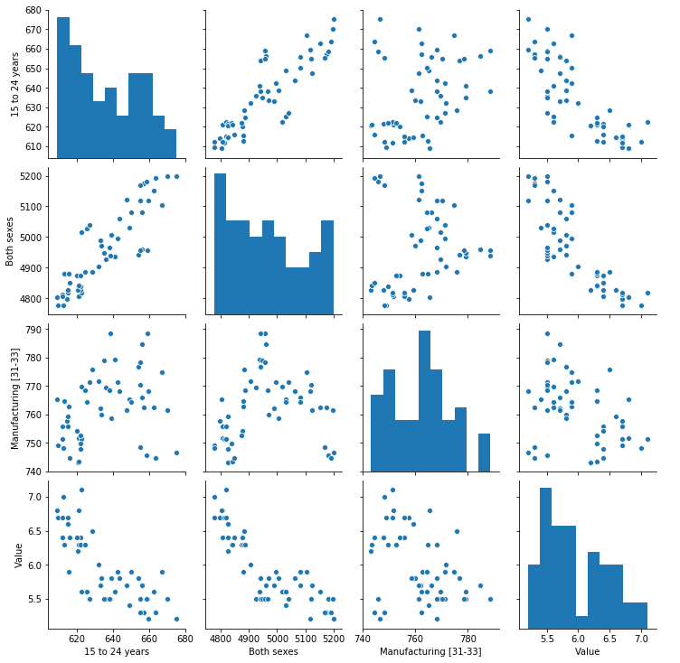

```python
pariplot_df = feature_df.copy()
pariplot_df['Value'] = on_unemp_rate_df['Value']
g = sns.pairplot(pariplot_df, vars=['15 to 24 years', 'Both sexes', 'Manufacturing [31-33]', 'Value'])
```

Some features are choosen to make a pair plot, in order to check the relation between different features. We can notice 'Both sexes' and 'Value' are inversely proportional, which means this feature will help us decide.

## 3.3 Make Training and TestDataSet

The index we want to predict is unemployment rate for one month in Ontario

```python
from sklearn.model_selection import train_test_split

y = on_unemp_rate_df['Value'].to_list()
X_train, X_test, y_train, y_test = train_test_split(X, y, test_size=0.3, random_state=1)
```

## 3.3 Select Model

```python
from sklearn.linear_model import Ridge
from sklearn.ensemble import RandomForestRegressor
from sklearn.tree import DecisionTreeRegressor
from sklearn.neural_network import MLPClassifier
from sklearn.svm import SVR

from sklearn.metrics import mean_squared_error
```

```python
'''
Choose different regressor algorithm, compare the result and choose the best one.
'''
regressor = [
    Ridge(alpha = .3),
    Ridge(alpha = .5),
    Ridge(alpha = .8),
    RandomForestRegressor(n_estimators = 80),
    DecisionTreeRegressor(),
    SVR()
]

cols = ['Regressor', 'MSE']
results = pd.DataFrame(columns=cols)

for reg in regressor:
    reg.fit(X_train, y_train)
    name = reg.__class__.__name__

    print('='*30)
    print(name)
    y_pred = reg.predict(X_test)
    mse = mean_squared_error(y_test, y_pred)
    print('Mean Squared Error: {:.2}\n'.format(mse))

    # Save result
    result_reg = pd.DataFrame([[name, mse]], columns=cols)
    results = results.append(result_reg)

print('*'*30)
```

```
==============================
Ridge
Mean Squared Error: 0.041

==============================
Ridge
Mean Squared Error: 0.041

==============================
Ridge
Mean Squared Error: 0.041

==============================
RandomForestRegressor
Mean Squared Error: 0.048

==============================
DecisionTreeRegressor
Mean Squared Error: 0.12

==============================
SVR
Mean Squared Error: 0.048
```

Ridge has the smallest error

```python
best_regressor = Ridge(alpha = .5)
```

# 3.4 Save Model

```python
import pickle
with open('model.pickle', 'wb') as fw:
    pickle.dump(best_regressor, fw)
```